# part1

please refer the table

joint probability of the people who planned to purchase and actually placed an order

```python
APO = 400
TO = 2000
Ans = (APO/TO)
print('joint probablity of people who planned to purchased and actually placed an order. is %1.4f' % Ans)
```

```
joint probablity of people who planned to purchased and actually placed an order. is 0.2000
```

joint probability of the people who planned to purchase and actually placed an order, given that people planned to purchase

```python
APO = 400
TO = 2000
GTP = 500
Ans = (APO/TO)/(GTP/TO)
print('joint probablity of people who planned to purchased and actually placed an order,given that people planned to purchased. is %1.4f' %Ans)
```

```
joint probablity of people who planned to purchased and actually placed an order,given that people planned to purchased. is 0.8000
```

# An electrical manufacturing company conducts quality checks at specified periods on the products it manufactures. Historically, thefailure rate for the manufactured item is 5%. Suppose a random sample of 10 manufactured items is selected. Answer the following questions

# 2.A. Probability that none of the items are defective?

```python
import numpy as np
import pandas as pd
import scipy.stats as stats
import matplotlib.pyplot as plt
```

```python
p = 0.05
n = 10
k = np. arange(0,11)
```

```python
binomial = stats.binom.pmf(k,n,p)
```

```python
print(binomial)
```

```
[5.98736939e-01 3.15124705e-01 7.46347985e-02 1.04750594e-02
 9.64808106e-04 6.09352488e-05 2.67259863e-06 8.03789062e-08
 1.58642578e-09 1.85546875e-11 9.76562500e-14]
```

```python
print('a) None of the items are defective? is %1.4f' %binomial[0])
```

```
a) None of the items are defective? is 0.5987
```

# 2.B. Probability that exactly one of the items is defective?

```python
print('b) exactly one of the items is defective? is %1.4f' %binomial[1])
```

```
b) exactly one of the items is defective? is 0.3151
```

# 2.C. Probability that two or fewer of the items are defective?

we need to calculate cumulative probability of Upto Two items being defective :

```python
cumbinomial = stats.binom.cdf(k,n,p)
```

```python
print(cumbinomial)
```

```
[0.59873694 0.91386164 0.98849644 0.9989715  0.99993631 0.99999725
 0.99999992 1.         1.         1.         1.        ]
```

```python
print('c) two or fewer of the items are defective? is %1.4f' %cumbinomial[2])
```

```
c) two or fewer of the items are defective? is 0.9885
```

# 2.D. Probability that three or more of the items are defective ?

we need to subtract cumulative Probability upto 2 items defective from 1.

```python
p = 1-cumbinomial[2]
print('d) three or more of the items are defective ? is %1.4f' %p)
```

```
d) three or more of the items are defective ? is 0.0115
```

# Q3. A car salesman sells on an average 3 cars per week

# 3.A. What is Probability that in a given week he will sell some cars?

```python
rate = 3
n = np.arange(0,16)
cumpoisson = stats.poisson.cdf(n,rate)
```

```python
cumpoisson
```

```
array([0.04978707, 0.19914827, 0.42319008, 0.64723189, 0.81526324,
       0.91608206, 0.96649146, 0.9880955 , 0.99619701, 0.99889751,
       0.99970766, 0.99992861, 0.99998385, 0.9999966 , 0.99999933,
       0.99999988])
```

```python
# p = probablity that the given week he wiil sells some cars
p = 1- cumpoisson[0]
print('a) probablity that the given week he will sell some cars is %1.4f' %p)
```

```
a) probablity that the given week he will sell some cars is 0.9502
```

# 3.B. What is Probability that in a given week he will sell 2 or more but less than 5 cars?

```python
# let p1 be the probablity that the given week he will sell some cars more than 4 cars
p1 = cumpoisson[4] #p(x >=4)
# let p2 be the probablity that given week he will sell some cars more than one cars
p2 = cumpoisson[1] #p(x >=1)
p = p1-p2
print('b) probablity that in a given week sell he will sell between 2 or more but less than 5 cars? is %1.4f' %p)
```

```
b) probablity that in a given week sell he will sell between 2 or more but less than 5 cars? is 0.6161
```

# 3.C. Plot the poisson distribution function for cumulative probability of cars sold per-week vs number of cars sold per week.

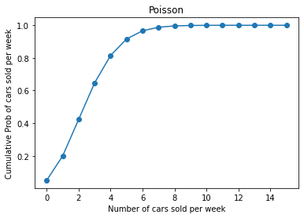

```python
poisson = stats.poisson.cdf(n,rate)
plt.plot(n,poisson, 'o-')
plt.title('Poisson')
plt.xlabel('Number of cars sold per week')
plt.ylabel('Cumulative Prob of cars sold per week')
plt.show()
```

# Q4. Accuracy in understanding orders for a speech based bot at a restaurant is important for the Company X which has designed,marketed and launched the product for a contactless delivery due to the COVID-19 pandemic. Recognition accuracy that measures the percentage of orders that are taken correctly is 86.8%. Suppose that you place an order with the bot and two friends of yours independently place orders with the same bot. Answer the following questions.

# 4.A. What is the probability that all three orders will be recognised correctly?

# 4.B. What is the probability that none of the three orders will be recognised correctly? [

# 4.C. What is the probability that at least two of the three orders will be recognised correctly?

# Answer:

Because there are three orders and the probablity of a correct order is 0.868.Using Binomial distribution equation,

p('x = 3|n = 3,pi given = 0.868') (3!/3!(3-3)!*(0.868)^3*(1-0.868)^3-3) = 0.6540

Likewise, calculate x = 0, x = 2 p(x = 0) = 0.0023 p(x=2) = 0.29

p(x>=2) = p(x=2) + p(x=3) = 0.9524

# Q5. Explain 1 real life industry scenario (other than the ones mentioned above) where you can use the concepts learnt in this module of Applied Statistics to get data driven business solution.

Marks obtained have a mean of 60 and a standard deviation of 12. There were 300 students who wrote the exam. The pattern of marks follows a normal distribution a) what is the percentage of students who score more than 80 b) What is the percentage of students who score less than 50 c) What should be the distinction mark if the highest 10% of students are to be awarded distinction? Graphical method can be used for convenience.

# Answer

a) Lets use the ztable that gives the area between 0 and positive z. Z = (x - µ)/σ (80 -60)/12 =1.67 proportions of students who score more than 1.67 = 0.5 - proportion scoring between 0 and 1.67 = 0.5 - 0.4525 = 0.0475 That is 4.75% of students have scored more than 80

b) similarly (50 - 60)/12 = -0.8333. Applying the property of symmetry, the area upto -0.8333 is same as area more than 0.8333 in the positive side. As before, it is = 0.5 - area between 0 and 0.8333 = 0.5 - 0.2967 = 0.2033. That is 20.33% of students scored below 50

c) Z = (x-60)/12. Here look at the normal tabel in inverse manner. That is the value of Z, the area between 0 and z = 0.40. this is to be seen from teh table. The Z value that will make the area = 0.40 is = 1.28. But z= (x - 60)/12. Hence (x-60)/12 = 1.28 Simplifying, x= 75.36 This is the distinction mark that will be scored by 10% of the students.

# PART-B

DOMAIN: Sports • CONTEXT: Company X manages the men's top professional basketball division of the American league system. The dataset contains information on all the teams that have participated in all the past tournaments. It has data about how many baskets each team scored, conceded, how many times they came within the first 2 positions, how many tournaments they have qualified, their best position in the past, etc. • DATA DESCRIPTION: Basketball.csv - The data set contains information on all the teams so far participated in all the past tournaments. • DATA DICTIONARY:

1. Team: Team’s name
2. Tournament: Number of played tournaments.
3. Score: Team’s score so far.
4. PlayedGames: Games played by the team so far.
5. WonGames: Games won by the team so far.
6. DrawnGames: Games drawn by the team so far.
7. LostGames: Games lost by the team so far.
8. BasketScored: Basket scored by the team so far.
9. BasketGiven: Basket scored against the team so far.
10. TournamentChampion: How many times the team was a champion of the tournaments so far.
11. Runner-up: How many times the team was a runners-up of the tournaments so far.
12. TeamLaunch: Year the team was launched on professional basketball.
13. HighestPositionHeld: Highest position held by the team amongst all the tournaments played. • PROJECT OBJECTIVE: Company’s management wants to invest on proposals on managing some of the best teams in the league. The analytics department has been assigned with a task of creating a report on the performance shown by the teams. Some of the older teams are already in contract with competitors. Hence Company X wants to understand which teams they can approach which will be a deal win for them
1. Read the data set, clean the data and prepare final dataset to be used for analysis.

```python
from google.colab import drive
drive.mount('/content/drive')
```

```python
# Importing packages
import numpy as np
import pandas as pd
import seaborn as sns
import matplotlib.pyplot as plt
from datetime import datetime
```

```python
import pandas as pd
data = pd.read_csv('/content/DS+-+Part2+-+Basketball (1).csv')
print(data.shape)
data.head()
```

```
(61, 13)
```

|  | Team | Tournament | Score | PlayedGames | WonGames | DrawnGames | LostGames | BasketScored | BasketGiven | TournamentChampion | Runner-up | TeamLaunch | HighestPositionHeld |
| --- | --- | --- | --- | --- | --- | --- | --- | --- | --- | --- | --- | --- | --- |
| 0 | Team 1 | 86 | 4385 | 2762 | 1647 | 552 | 563 | 5947 | 3140 | 33 | 23 | 1929 | 1 |
| 1 | Team 2 | 86 | 4262 | 2762 | 1581 | 573 | 608 | 5900 | 3114 | 25 | 25 | 1929 | 1 |
| 2 | Team 3 | 80 | 3442 | 2614 | 1241 | 598 | 775 | 4534 | 3309 | 10 | 8 | 1929 | 1 |
| 3 | Team 4 | 82 | 3386 | 2664 | 1187 | 616 | 861 | 4398 | 3469 | 6 | 6 | 1931to32 | 1 |
| 4 | Team 5 | 86 | 3368 | 2762 | 1209 | 633 | 920 | 4631 | 3700 | 8 | 7 | 1929 | 1 |

```python
# Reading the data and getting first five rows for viewing
Basketball_raw = pd.read_csv('/content/DS+-+Part2+-+Basketball (1).csv')
Basketball_raw.head()
```

|  | Team | Tournament | Score | PlayedGames | WonGames | DrawnGames | LostGames | BasketScored | BasketGiven | TournamentChampion | Runner-up | TeamLaunch | HighestPositionHeld |
| --- | --- | --- | --- | --- | --- | --- | --- | --- | --- | --- | --- | --- | --- |
| 0 | Team 1 | 86 | 4385 | 2762 | 1647 | 552 | 563 | 5947 | 3140 | 33 | 23 | 1929 | 1 |
| 1 | Team 2 | 86 | 4262 | 2762 | 1581 | 573 | 608 | 5900 | 3114 | 25 | 25 | 1929 | 1 |
| 2 | Team 3 | 80 | 3442 | 2614 | 1241 | 598 | 775 | 4534 | 3309 | 10 | 8 | 1929 | 1 |
| 3 | Team 4 | 82 | 3386 | 2664 | 1187 | 616 | 861 | 4398 | 3469 | 6 | 6 | 1931to32 | 1 |
| 4 | Team 5 | 86 | 3368 | 2762 | 1209 | 633 | 920 | 4631 | 3700 | 8 | 7 | 1929 | 1 |

EXPLORE THE DATA

```python
data.dtypes
```

```
Team                   object
Tournament              int64
Score                  object
PlayedGames            object
WonGames               object
DrawnGames             object
LostGames              object
BasketScored           object
BasketGiven            object
TournamentChampion     object
Runner-up              object
TeamLaunch             object
HighestPositionHeld     int64
dtype: object
```

```python
# Checking data types for each attributes in data
Basketball_raw.dtypes
```

```
Team                   object
Tournament              int64
Score                  object
PlayedGames            object
WonGames               object
DrawnGames             object
LostGames              object
BasketScored           object
BasketGiven            object
TournamentChampion     object
Runner-up              object
TeamLaunch             object
HighestPositionHeld     int64
dtype: object
```

**Numerical attributes:int64** Tournament, HighestPositionHeld

**Inference from Attribute check**  
From problem definition, names of the attributes (with meaning) and data types check,  
1. Data type for the following attribute must be Numerical since these are Quantitative variables: Tournament, Score , PlayedGames, WonGames, DrawnGames, LostGames, BasketScored, BasketGiven TournamentChampion, Runner-up  
2. Data type for the following attribute must be datetime as are year of Launch:TeamLaunch  
3. Data type for the following attribute must be string since variable is nominal: Team

```python
# Checking the dataset for standard null v
data.dtypes.isnull().values.any()
```

```
False
```

```python
data.isna().sum()
```

```
Team                   0
Tournament             0
Score                  0
PlayedGames            0
WonGames               0
DrawnGames             0
LostGames              0
BasketScored           0
BasketGiven            0
TournamentChampion     0
Runner-up              0
TeamLaunch             0
HighestPositionHeld    0
dtype: int64
```

```python
df1 = data.dropna().copy(deep=True)
```

**Inference**  
It can be seen from above check that there is no null value in the data set based on current data types for attributes.  
But, after changing the data type to the correct one (based on type of variable), Null values need to be checked again.

## Data preprocessing and Visualization

```python
# Setting correct data type for each attribute of the data

# Convert Team column to string data type
str_attr = Basketball_raw["Team"].astype(str)

# Convert relevant columns to numerical attribute
numerics_columns = ["Tournament", "Score", "PlayedGames", "WonGames", "DrawnGames", "LostGames", "BasketScored", "BasketGiven", "TournamentChampion" , "Runner-up","HighestPositionHeld"]
num_attr = Basketball_raw[numerics_columns].apply(pd.to_numeric, errors="coerce")

# Convert relevant columns to date and time attribute
dtTime_attr = Basketball_raw["TeamLaunch"].apply(pd.to_datetime, errors="coerce")

Basketball = pd.concat([str_attr , num_attr, dtTime_attr], axis=1, join="inner")

print(type(Basketball))
print(Basketball.shape)
Basketball.dtypes
#Basketball.head
```

```
<class 'pandas.core.frame.DataFrame'>
(61, 13)
```

```
Team                           object
Tournament                      int64
Score                         float64
PlayedGames                   float64
WonGames                      float64
DrawnGames                    float64
LostGames                     float64
BasketScored                  float64
BasketGiven                   float64
TournamentChampion            float64
Runner-up                     float64
HighestPositionHeld             int64
TeamLaunch             datetime64[ns]
dtype: object
```

```python
# Check NAN values
Basketball.isnull().values.any()
Basketball.isnull().sum().sum()
# Number of missing values (only the ones recognised as missing values) in each of the attributes
pd.DataFrame( Basketball.isnull().sum(), columns= ['Number of missing values'])
```

|  | Number of missing values |
| --- | --- |
| Team | 0 |
| Tournament | 0 |
| Score | 1 |
| PlayedGames | 1 |
| WonGames | 1 |
| DrawnGames | 1 |
| LostGames | 1 |
| BasketScored | 1 |
| BasketGiven | 1 |
| TournamentChampion | 52 |
| Runner-up | 48 |
| HighestPositionHeld | 0 |
| TeamLaunch | 49 |

```python
# Handling NAN values for each attribute one by one
Basketball['Score'].fillna(0, inplace = True)
Basketball['PlayedGames'].fillna(0, inplace = True)
Basketball['WonGames'].fillna(0, inplace = True)
Basketball['DrawnGames'].fillna(0, inplace = True)
Basketball['LostGames'].fillna(0, inplace = True)
Basketball['BasketScored'].fillna(0, inplace = True)
Basketball['BasketGiven'].fillna(0, inplace = True)
Basketball['TournamentChampion'].fillna(0, inplace = True)
Basketball['Runner-up'].fillna(0, inplace = True)

# Again check Number of missing values (only the ones recognised as missing values) in each of the attributes
pd.DataFrame( Basketball.isnull().sum(), columns= ['Number of missing values'])
```

|  | Number of missing values |
| --- | --- |
| Team | 0 |
| Tournament | 0 |
| Score | 0 |
| PlayedGames | 0 |
| WonGames | 0 |
| DrawnGames | 0 |
| LostGames | 0 |
| BasketScored | 0 |
| BasketGiven | 0 |
| TournamentChampion | 0 |
| Runner-up | 0 |
| HighestPositionHeld | 0 |
| TeamLaunch | 49 |

```python
df1['WonGames'].sample(5)
```

```
25     184
27     145
3     1187
36      62
50      29
Name: WonGames, dtype: object
```

```python
df1['Tournament'].sample(5)
```

```
32    12
36     6
19    33
59     1
7     70
Name: Tournament, dtype: int64
```

```python
df1.sample(3)
```

|  | Team | Tournament | Score | PlayedGames | WonGames | DrawnGames | LostGames | BasketScored | BasketGiven | TournamentChampion | Runner-up | TeamLaunch | HighestPositionHeld |
| --- | --- | --- | --- | --- | --- | --- | --- | --- | --- | --- | --- | --- | --- |
| 19 | Team 20 | 33 | 1020 | 1096 | 367 | 242 | 487 | 1347 | 1746 | - | 1 | 1951-52 | 2 |
| 11 | Team 12 | 51 | 1789 | 1698 | 586 | 389 | 723 | 2278 | 2624 | - | - | 1939-40 | 4 |
| 30 | Team 31 | 12 | 375 | 423 | 123 | 102 | 198 | 422 | 581 | - | - | 1974-75 | 7 |

# Q2. Perform detailed statistical analysis and EDA using univariate, bi-variate and multivariate EDA techniques to get data driven insights on

recommending which teams they can approach which will be a deal win for them. Also as a data and statistics expert you have to develop a detailed performance report using this data.

```python
import pandas as pd
import matplotlib.pyplot as plt
import seaborn as sns
import warnings
warnings.filterwarnings("ignore")
from PIL import Image
```

```python
data = pd.read_csv('/content/DS+-+Part2+-+Basketball (1).csv')
```

```python
## Best performing team
Highest_PWin = Basketball['WonGames']/Basketball['PlayedGames']
Basketball.loc[Highest_PWin.idxmax(axis = 0)]
```

```
Team                                Team 1
Tournament                              86
Score                               4385.0
PlayedGames                         2762.0
WonGames                            1647.0
DrawnGames                           552.0
LostGames                            563.0
BasketScored                        5947.0
BasketGiven                         3140.0
TournamentChampion                    33.0
Runner-up                             23.0
HighestPositionHeld                      1
TeamLaunch             1929-01-01 00:00:00
Name: 0, dtype: object
```

So Team 1 is Best performing team based on winning percentage

```python
## oldest team
Basketball.loc[Basketball["TeamLaunch"].idxmin(axis = 0)]
```

```
Team                                Team 1
Tournament                              86
Score                               4385.0
PlayedGames                         2762.0
WonGames                            1647.0
DrawnGames                           552.0
LostGames                            563.0
BasketScored                        5947.0
BasketGiven                         3140.0
TournamentChampion                    33.0
Runner-up                             23.0
HighestPositionHeld                      1
TeamLaunch             1929-01-01 00:00:00
Name: 0, dtype: object
```

```python
## Team with lowest performance
Highest_PLost = Basketball['LostGames']/Basketball['PlayedGames']
Basketball.loc[Highest_PLost.idxmax(axis = 0)]
```

```
Team                   Team 60
Tournament                   1
Score                     14.0
PlayedGames               30.0
WonGames                   5.0
DrawnGames                 4.0
LostGames                 21.0
BasketScored              34.0
BasketGiven               65.0
TournamentChampion         0.0
Runner-up                  0.0
HighestPositionHeld         15
TeamLaunch                 NaT
Name: 59, dtype: object
```

So Team 60 is the team with lowest performance based on Lost game percentage

```python
data = data['Tournament']
```

```python
len(data)
```

```
61
```

```python
data.isnull().sum()
```

```
0
```

```python
data = data.dropna()
```

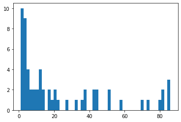

```python
# The following code plots a histrogram using the matplotlib package.
# The bins argument creates class intervals. In this case we are creating 50 such intervals
plt.hist(data, bins=50)
```

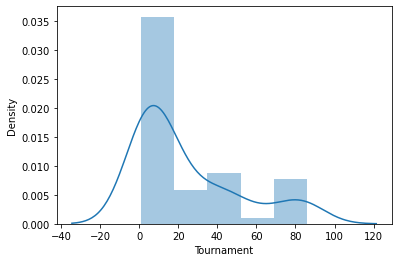

```python
sns.distplot(data) # plots a frequency polygon superimposed on a histogram using the seaborn package.
# seaborn automatically creates class intervals. The number of bins can also be manually set.
```

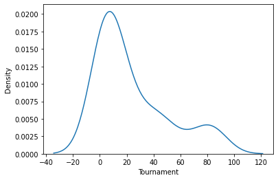

```python
sns.distplot(data, hist=False) # adding an argument to plot only frequency polygon
```

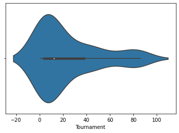

```python
sns.violinplot(data) # plots a violin plt using the seaborn package.
```

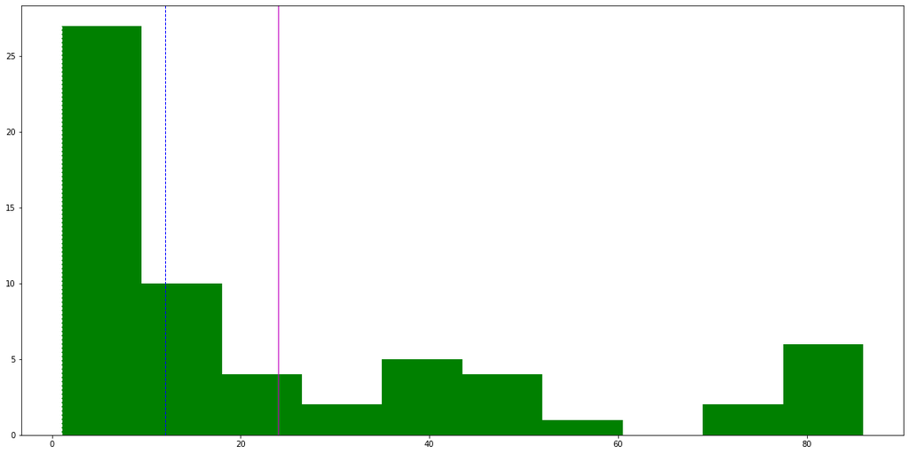

```python
plt.figure(figsize=(20,10)) # makes the plot wider
plt.hist(data, color='g') # plots a simple histogram
plt.axvline(data.mean(), color='m', linewidth=1)
plt.axvline(data.median(), color='b', linestyle='dashed', linewidth=1)
plt.axvline(data.mode()[0], color='w', linestyle='dashed', linewidth=1)
```

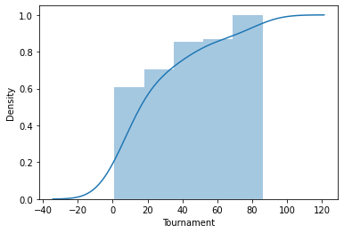

```python
sns.distplot(data, hist_kws=dict(cumulative=True), kde_kws=dict(cumulative=True))
```

#### A Scatter plot gives us an idea of the association between two variables

```python
data1 = pd.read_csv('/content/DS+-+Part2+-+Basketball (1).csv')
```

```python
data1.head()
```

[output not shown]

```python
data1 = data1.dropna()
```

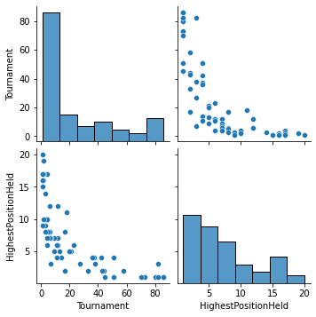

```python
sns.pairplot(data1)
```

**A scatter plot can also be plotted for two individual columns:**

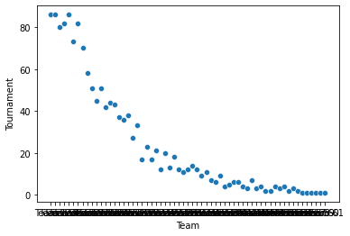

```python
sns.scatterplot(data1['Team'], data1['Tournament'])  # Plots the scatter plot using two variables
```

**The scatter plot only offers visual information about the degree of correlation. In order to obtain more precise information we can use the inbuilt .corr() method in Pandas. This returns a table with all the correlations calculated for the numerical columns.**

```python
data1.corr()   # displays the correlation between every possible pair of attributes as a dataframe
```

|  | Tournament | HighestPositionHeld |
| --- | --- | --- |
| Tournament | 1.000000 | -0.708071 |
| HighestPositionHeld | -0.708071 | 1.000000 |

**The same can be represented graphically using a the heatmap function in seaborn.**

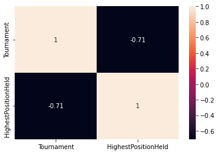

```python
sns.heatmap(data1.corr(), annot=True)  # plot the correlation coefficients as a heatmap
```

**Another way of looking at multivariate scatter plot is to use the hue option in the scatterplot() function in seaborn.**

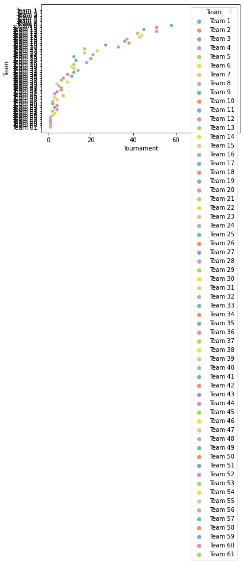

```python
sns.scatterplot(data1['Tournament'], data1['Team'], hue=data1['Team'], palette='Set2')
```

# Handling non-numeric(Categorical) data

#### One Hot Encoding

One-Hot-Encoding is used to create dummry variables to replace the categories in a categorical variable into features of each category and represent it using 1 or 0 based on the presence or absence of the categorical value in the record

```python
df_dummies= pd.get_dummies(data1, prefix='Team', columns=['Tournament']) #This function does One-Hot-Encoding on categorical text
```

```python
df_dummies.head()
```

|  | Team | Score | PlayedGames | WonGames | DrawnGames | LostGames | BasketScored | BasketGiven | TournamentChampion | Runner-up | ... | Team_43 | Team_44 | Team_45 | Team_51 | Team_58 | Team_70 | Team_73 | Team_80 | Team_82 | Team_86 |
| --- | --- | --- | --- | --- | --- | --- | --- | --- | --- | --- | --- | --- | --- | --- | --- | --- | --- | --- | --- | --- | --- |
| 0 | Team 1 | 4385 | 2762 | 1647 | 552 | 563 | 5947 | 3140 | 33 | 23 | ... | 0 | 0 | 0 | 0 | 0 | 0 | 0 | 0 | 0 | 1 |
| 1 | Team 2 | 4262 | 2762 | 1581 | 573 | 608 | 5900 | 3114 | 25 | 25 | ... | 0 | 0 | 0 | 0 | 0 | 0 | 0 | 0 | 0 | 1 |
| 2 | Team 3 | 3442 | 2614 | 1241 | 598 | 775 | 4534 | 3309 | 10 | 8 | ... | 0 | 0 | 0 | 0 | 0 | 0 | 0 | 1 | 0 | 0 |
| 3 | Team 4 | 3386 | 2664 | 1187 | 616 | 861 | 4398 | 3469 | 6 | 6 | ... | 0 | 0 | 0 | 0 | 0 | 0 | 0 | 0 | 1 | 0 |
| 4 | Team 5 | 3368 | 2762 | 1209 | 633 | 920 | 4631 | 3700 | 8 | 7 | ... | 0 | 0 | 0 | 0 | 0 | 0 | 0 | 0 | 0 | 1 |

5 rows × 45 columns

```python
df_dummies.columns   # returns the names of all the columns as a list
```

```
Index(['Team', 'Score', 'PlayedGames', 'WonGames', 'DrawnGames', 'LostGames',
       'BasketScored', 'BasketGiven', 'TournamentChampion', 'Runner-up',
       'TeamLaunch', 'HighestPositionHeld', 'Team_1', 'Team_2', 'Team_3',
       'Team_4', 'Team_5', 'Team_6', 'Team_7', 'Team_9', 'Team_11', 'Team_12',
       'Team_13', 'Team_14', 'Team_17', 'Team_18', 'Team_20', 'Team_21',
       'Team_23', 'Team_27', 'Team_33', 'Team_36', 'Team_37', 'Team_38',
       'Team_42', 'Team_43', 'Team_44', 'Team_45', 'Team_51', 'Team_58',
       'Team_70', 'Team_73', 'Team_80', 'Team_82', 'Team_86'],
      dtype='object')
```

```python
from sklearn.preprocessing import LabelEncoder   # import label encoder

labelencoder = LabelEncoder()

df_dummies['WonGameId'] = labelencoder.fit_transform(df_dummies.Team) # returns label encoded variable(s)
```

```python
df_dummies['WonGameId'].head(5)
```

```
0     0
1    11
2    22
3    33
4    44
Name: WonGameId, dtype: int64
```

```python
df_dummies['WonGameId'].value_counts()   # Number of entries of each class
```

```
0     1
25    1
27    1
28    1
29    1
     ..
18    1
19    1
20    1
21    1
57    1
Name: WonGameId, Length: 61, dtype: int64
```

```python
df_dummies['WonGameId'].unique()   # All the unique classes
```

```
array([ 0, 11, 22, 33, 44, 55, 58, 59, 60,  1,  2,  3,  4,  5,  6,  7,  8,
        9, 10, 12, 13, 14, 15, 16, 17, 18, 19, 20, 21, 23, 24, 25, 26, 27,
       28, 29, 30, 31, 32, 34, 35, 36, 37, 38, 39, 40, 41, 42, 43, 45, 46,
       47, 48, 49, 50, 51, 52, 53, 54, 56, 57])
```

```python
df_dummies['WonGameId'].nunique()  # number of unique classes
```

```
61
```

```python
from sklearn.preprocessing import OneHotEncoder
hotencoder = OneHotEncoder()
encoded = hotencoder.fit_transform(df_dummies.WonGameId.values.reshape(-1,1)).toarray()
# Returns a numpy array of one hot encoded variables
encoded
```

```
array([[1., 0., 0., ..., 0., 0., 0.],
       [0., 0., 0., ..., 0., 0., 0.],
       [0., 0., 0., ..., 0., 0., 0.],
       ...,
       [0., 0., 0., ..., 0., 0., 0.],
       [0., 0., 0., ..., 0., 0., 0.],
       [0., 0., 0., ..., 0., 0., 0.]])
```

```python
encoded.shape
```

```
(61, 61)
```

```python
# convert the array into a dataframe. Specifically, one hot encoded dataframe

df_encoded = pd.DataFrame(encoded, columns = ["WonGameId_"+str(int(i)) for i in range(encoded.shape[1])])
```

```python
df_encoded.head()
```

|  | WonGameId_0 | WonGameId_1 | WonGameId_2 | WonGameId_3 | WonGameId_4 | WonGameId_5 | WonGameId_6 | WonGameId_7 | WonGameId_8 | WonGameId_9 | ... | WonGameId_51 | WonGameId_52 | WonGameId_53 | WonGameId_54 | WonGameId_55 | WonGameId_56 | WonGameId_57 | WonGameId_58 | WonGameId_59 | WonGameId_60 |
| --- | --- | --- | --- | --- | --- | --- | --- | --- | --- | --- | --- | --- | --- | --- | --- | --- | --- | --- | --- | --- | --- |
| 0 | 1.0 | 0.0 | 0.0 | 0.0 | 0.0 | 0.0 | 0.0 | 0.0 | 0.0 | 0.0 | ... | 0.0 | 0.0 | 0.0 | 0.0 | 0.0 | 0.0 | 0.0 | 0.0 | 0.0 | 0.0 |
| 1 | 0.0 | 0.0 | 0.0 | 0.0 | 0.0 | 0.0 | 0.0 | 0.0 | 0.0 | 0.0 | ... | 0.0 | 0.0 | 0.0 | 0.0 | 0.0 | 0.0 | 0.0 | 0.0 | 0.0 | 0.0 |
| 2 | 0.0 | 0.0 | 0.0 | 0.0 | 0.0 | 0.0 | 0.0 | 0.0 | 0.0 | 0.0 | ... | 0.0 | 0.0 | 0.0 | 0.0 | 0.0 | 0.0 | 0.0 | 0.0 | 0.0 | 0.0 |
| 3 | 0.0 | 0.0 | 0.0 | 0.0 | 0.0 | 0.0 | 0.0 | 0.0 | 0.0 | 0.0 | ... | 0.0 | 0.0 | 0.0 | 0.0 | 0.0 | 0.0 | 0.0 | 0.0 | 0.0 | 0.0 |
| 4 | 0.0 | 0.0 | 0.0 | 0.0 | 0.0 | 0.0 | 0.0 | 0.0 | 0.0 | 0.0 | ... | 0.0 | 0.0 | 0.0 | 0.0 | 0.0 | 0.0 | 0.0 | 0.0 | 0.0 | 0.0 |

5 rows × 61 columns

```python
df_encoded.shape
```

```
(61, 61)
```

```python
df_dummies = pd.concat([df_dummies, df_encoded], axis=1)  # concats two dataframes
```

```python
df_dummies.head(5)
```

|  | Team | Score | PlayedGames | WonGames | DrawnGames | LostGames | BasketScored | BasketGiven | TournamentChampion | Runner-up | ... | WonGameId_51 | WonGameId_52 | WonGameId_53 | WonGameId_54 | WonGameId_55 | WonGameId_56 | WonGameId_57 | WonGameId_58 | WonGameId_59 | WonGameId_60 |
| --- | --- | --- | --- | --- | --- | --- | --- | --- | --- | --- | --- | --- | --- | --- | --- | --- | --- | --- | --- | --- | --- |
| 0 | Team 1 | 4385 | 2762 | 1647 | 552 | 563 | 5947 | 3140 | 33 | 23 | ... | 0.0 | 0.0 | 0.0 | 0.0 | 0.0 | 0.0 | 0.0 | 0.0 | 0.0 | 0.0 |
| 1 | Team 2 | 4262 | 2762 | 1581 | 573 | 608 | 5900 | 3114 | 25 | 25 | ... | 0.0 | 0.0 | 0.0 | 0.0 | 0.0 | 0.0 | 0.0 | 0.0 | 0.0 | 0.0 |
| 2 | Team 3 | 3442 | 2614 | 1241 | 598 | 775 | 4534 | 3309 | 10 | 8 | ... | 0.0 | 0.0 | 0.0 | 0.0 | 0.0 | 0.0 | 0.0 | 0.0 | 0.0 | 0.0 |
| 3 | Team 4 | 3386 | 2664 | 1187 | 616 | 861 | 4398 | 3469 | 6 | 6 | ... | 0.0 | 0.0 | 0.0 | 0.0 | 0.0 | 0.0 | 0.0 | 0.0 | 0.0 | 0.0 |
| 4 | Team 5 | 3368 | 2762 | 1209 | 633 | 920 | 4631 | 3700 | 8 | 7 | ... | 0.0 | 0.0 | 0.0 | 0.0 | 0.0 | 0.0 | 0.0 | 0.0 | 0.0 | 0.0 |

5 rows × 107 columns

# Normalization and Scaling

In this method, we convert variables with different scales of measurements into a single scale.

```python
#Scales the data. Essentially returns the z-scores of every attribute

from sklearn.preprocessing import StandardScaler

std_scale = StandardScaler()

std_scale
```

```
StandardScaler()
```

MinMaxScaler normalizes the data using the formula (x - min)/(max - min)

```python
from sklearn.preprocessing import MinMaxScaler

minmax_scale = MinMaxScaler()

minmax_scale
```

```
MinMaxScaler()
```

Log Transformation

We are going to write a custom transformer to perform log transformation

```python
import numpy as np
```

```python
# Transform an attribute using a mathematical transformation.
# We might want to do that to change the distribution shape of the data
from sklearn.preprocessing import FunctionTransformer

log_transformer = FunctionTransformer(np.log1p)

log_transformer
```

```
FunctionTransformer(func=<ufunc 'log1p'>)
```

```python
data1['Tournament']= data1['Tournament'].fillna(data1['Tournament'].mean())  # impute the null values using the mean
```

```python
data1['Tournament_logtransform'] = log_transformer.fit_transform(data1[['Tournament']])   # Log Transform the attribute
```

```python
data1['Tournament_logtransform'].head()
```

```
0    4.465908
1    4.465908
2    4.394449
3    4.418841
4    4.465908
Name: Tournament_logtransform, dtype: float64
```

**Exponential Transformation**

```python
exp_transformer = FunctionTransformer(np.exp) # Exponential transform

exp_transformer
```

```
FunctionTransformer(func=<ufunc 'exp'>)
```

PART-C

m • CONTEXT: Company X is a EU online publisher focusing on the startups industry. The company specifically reports on the business related to technology news, analysis of emerging trends and profiling of new tech businesses and products. Their event i.e. Startup Battlefield is the world’s pre-eminent startup competition. Startup Battlefield features 15-30 top early stage startups pitching top judges in front of a vast live audience, present in person and online. • DATA DESCRIPTION: CompanyX_EU.csv - Each row in the dataset is a Start-up company and the columns describe the company. • DATA DICTIONARY:

1. Startup: Name of the company
2. Product: Actual product
3. Funding: Funds raised by the company in USD
4. Event: The event the company participated in
5. Result: Described by Contestant, Finalist, Audience choice, Winner or Runner up
6. OperatingState: Current status of the company, Operating ,Closed, Acquired or IPO *Dataset has been downloaded from the internet. All the credit for the dataset goes to the original creator of the data. • PROJECT OBJECTIVE: Analyse the data of the various companies from the given dataset and perform the tasks that are specified in the below steps. Draw insights from the various attributes that are present in the dataset, plot distributions, state hypotheses and draw conclusions from the dataset.

```python
# Importing packages
import numpy as np
import pandas as pd
import seaborn as sns
import matplotlib.pyplot as plt
from datetime import datetime
from scipy import stats
```

```python
# Reading the data and getting first five rows for viewing
CompanyX_EU_raw = pd.read_csv('/content/DS+-+Part3+-+CompanyX_EU.csv')
CompanyX_EU_raw.head()
```

|  | Startup | Product | Funding | Event | Result | OperatingState |
| --- | --- | --- | --- | --- | --- | --- |
| 0 | 2600Hz | 2600hz.com | NaN | Disrupt SF 2013 | Contestant | Operating |
| 1 | 3DLT | 3dlt.com | $630K | Disrupt NYC 2013 | Contestant | Closed |
| 2 | 3DPrinterOS | 3dprinteros.com | NaN | Disrupt SF 2016 | Contestant | Operating |
| 3 | 3Dprintler | 3dprintler.com | $1M | Disrupt NY 2016 | Audience choice | Operating |
| 4 | 42 Technologies | 42technologies.com | NaN | Disrupt NYC 2013 | Contestant | Operating |

DATA EXPLORATION

```python
# Check the shape of the data
CompanyX_EU_raw.shape
```

```
(662, 6)
```

```python
# Checking data types for each attributes in data
CompanyX_EU_raw.dtypes
```

```
Startup           object
Product           object
Funding           object
Event             object
Result            object
OperatingState    object
dtype: object
```

```python
# Checking the dataset for null value
CompanyX_EU_raw.isnull().values.any()
```

```
True
```

DATA PROCESING AND VISUALIZATION

```python
# Drop null values
CompanyX_EU = CompanyX_EU_raw.dropna()
CompanyX_EU.shape
```

```
(446, 6)
```

```python
# Change attribute to numeric for Funding
#CompanyX_EU["Funding"].apply(pd.to_numeric, errors="coerce")
CompanyX_EU["Funding"] = CompanyX_EU["Funding"].str.replace('$', '')

powers = {'B': 10 ** 9 , 'M': 10 ** 6, 'K': 10 ** 6}

def value(s):
    try:
        power = s[-1]
        return float(s[:-1]) * powers[power]
    except TypeError:
        return s

CompanyX_EU["Funding"] = CompanyX_EU["Funding"].apply(value);
```

```python
CompanyX_EU.dtypes
```

```
Startup            object
Product            object
Funding           float64
Event              object
Result             object
OperatingState     object
dtype: object
```

```python
Funds_millions = pd.DataFrame(CompanyX_EU["Funding"])
type(Funds_millions)
Funds_millions.head;
```

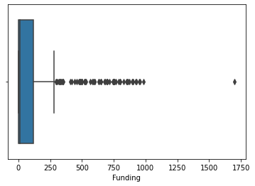

```python
Funds_millions = Funds_millions["Funding"]/10**6
Funds_millions.dropna(inplace=True);
sns.boxplot(Funds_millions);
```

```python
## Lower fence = Q1 — (1.5 * IQR).
Q1 = Funds_millions.quantile(q=0.25)
Q3 = Funds_millions.quantile(q=0.75)
IQR = Q3 - Q1
LowerFence = Q1 - (1.5*IQR)
print("Lower Fence for Funding in millions: ", LowerFence)
```

```
Lower Fence for Funding in millions:  -172.5
```

Since funding cant be negative. Its equal to 0.

```python
## Calculate the upper Fence
UpperFence = Q3 + (1.5*IQR)
print("Upper Fence =", UpperFence)
```

```
Upper Fence = 295.5
```

```python
## Outliers = Values greater than Upper fence
Number_Outliers = Funds_millions[Funds_millions>UpperFence].count()
print("Number of Outliers =", Number_Outliers)
```

```
Number of Outliers = 80
```

```python
## Drop values greater than Upper Fense in dataframe
CompanyX_EU.drop("Funding", inplace=True, axis=1);
CompanyX_EU["Funding"] = Funds_millions;
CompanyX_EU = CompanyX_EU[CompanyX_EU["Funding"] < UpperFence]
```

```python
CompanyX_EU.shape
```

```
(366, 6)
```

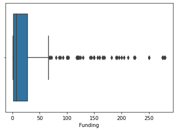

```python
sns.boxplot(CompanyX_EU["Funding"]);
```

from previous box plot that new dataset for Funding has different median, IQR and has outliers

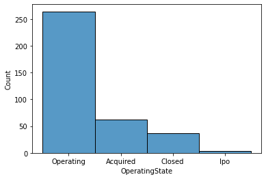

```python
# Frequency plot of the OperatingState features classes.
sns.histplot(data=CompanyX_EU["OperatingState"]);
```

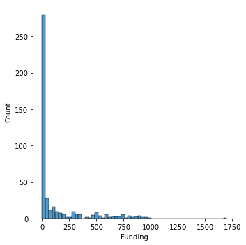

```python
# Plot a distribution plot for Funds in million without removing outliers.
sns.displot(Funds_millions, kind="hist");
```

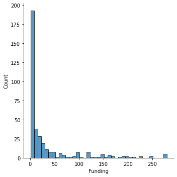

```python
# Plot a distribution plot for Funds in million by removing outliers.
sns.displot(CompanyX_EU["Funding"], kind="hist");
```

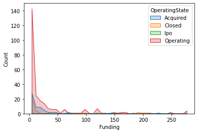

```python
# Plot distribution plots for companies still operating and companies that closed.
sns.histplot(CompanyX_EU,x=CompanyX_EU["Funding"], hue="OperatingState", element="poly");
```

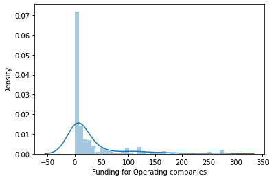

```python
# Plot distribution plots for companies still operating and companies that closed.
CompanyX_EU["OperatingState"]= CompanyX_EU["OperatingState"].astype('category')
Oper_CompanyX_EU = CompanyX_EU["Funding"][CompanyX_EU['OperatingState'] == "Operating"]
Closed_CompanyX_EU = CompanyX_EU["Funding"][CompanyX_EU["OperatingState"] == "Closed"]
sns.distplot(Oper_CompanyX_EU, axlabel="Funding for Operating companies");
```

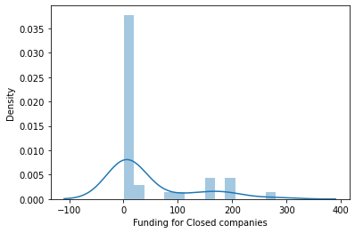

```python
sns.distplot(Closed_CompanyX_EU, axlabel="Funding for Closed companies");
```

```python
!jupyter nbconvert --to html "/content/drive/MyDrive/GL_Learning/Assignments/ComputerVision/Project_1/CV_Project_1.ipynb/content/Nayan_statistics_FinalProject (1).ipynb"
```

[output not shown]

[output cut: 107 more lines]

[output not shown]